# Homework 11

Javier Vidal

2025-02-20

## Instructions

Answer the following questions and complete the exercises in RMarkdown. Please embed all of your code and push your final work to your repository. Your final lab report should be organized, clean, and run free from errors. Remember, you must remove the `#` for the included code chunks to run. Be sure to add your name to the author header above.

Make sure to use the formatting conventions of RMarkdown to make your report neat and clean!

## Background

In the `data` folder, you will find data about shark incidents in California between 1950-2022. The [data](https://catalog.data.gov/dataset/shark-incident-database-california-56167) are from: State of California- Shark Incident Database.

## Load the libraries

```r
library("tidyverse")
library("janitor")
library("naniar")
```

## Load the data

Run the following code chunk to import the data.

```r
sharks <- read_csv("data/SharkIncidents_1950_2022_220302.csv") %>% clean_names()
```

## Questions

1. Start by doing some data exploration using your preferred function(s). What is the structure of the data? Where are the missing values and how are they represented?

```r
glimpse(sharks)
```

```
## Rows: 211
## Columns: 16
## $ incident_num     <chr> "1", "2", "3", "4", "5", "6", "7", "8", "9", "10", "1…
## $ month            <dbl> 10, 5, 12, 2, 8, 4, 10, 5, 6, 7, 10, 11, 4, 5, 5, 8, …
## $ day              <dbl> 8, 27, 7, 6, 14, 28, 12, 7, 14, 28, 4, 10, 24, 19, 21…
## $ year             <dbl> 1950, 1952, 1952, 1955, 1956, 1957, 1958, 1959, 1959,…
## $ time             <chr> "12:00", "14:00", "14:00", "12:00", "16:30", "13:30",…
## $ county           <chr> "San Diego", "San Diego", "Monterey", "Monterey", "Sa…
## $ location         <chr> "Imperial Beach", "Imperial Beach", "Lovers Point", "…
## $ mode             <chr> "Swimming", "Swimming", "Swimming", "Freediving", "Sw…
## $ injury           <chr> "major", "minor", "fatal", "minor", "major", "fatal",…
## $ depth            <chr> "surface", "surface", "surface", "surface", "surface"…
## $ species          <chr> "White", "White", "White", "White", "White", "White",…
## $ comment          <chr> "Body Surfing, bit multiple times on leg, thigh and b…
## $ longitude        <chr> "-117.1466667", "-117.2466667", "-122.05", "-122.15",…
## $ latitude         <dbl> 32.58833, 32.58833, 36.62667, 36.62667, 35.13833, 35.…
## $ confirmed_source <chr> "Miller/Collier, Coronado Paper, Oceanside Paper", "G…
## $ wfl_case_number  <chr> NA, NA, NA, NA, NA, NA, NA, NA, NA, NA, NA, NA, NA, N…
```

The missing values are represented as NOT COUNTED

2. Notice that there are some incidents identified as “NOT COUNTED”. These should be removed from the data because they were either not sharks, unverified, or were provoked. It’s OK to replace the `sharks` object.

```r
sharks <- read_csv("data/SharkIncidents_1950_2022_220302.csv", na = c("NOT COUNTED", "NA", "major*", "minor*", "none*")) %>% clean_names()
```

3. Are there any “hotspots” for shark incidents in California? Make a table and plot that shows the total number of incidents per county. Which county has the highest number of incidents?

```r
sharks %>%
 group_by(county) %>%
  summarize(total_incidents = n_distinct(incident_num)) %>%
  arrange(desc(total_incidents))
```

```
## # A tibble: 22 × 2
##    county          total_incidents
##    <chr>                     <int>
##  1 San Diego                    24
##  2 Humboldt                     19
##  3 San Mateo                    19
##  4 Santa Barbara                19
##  5 Marin                        16
##  6 Monterey                     16
##  7 Santa Cruz                   15
##  8 Sonoma                       15
##  9 San Luis Obispo              14
## 10 Los Angeles                  10
## # ℹ 12 more rows
```

San Diego has the highest number of incidents

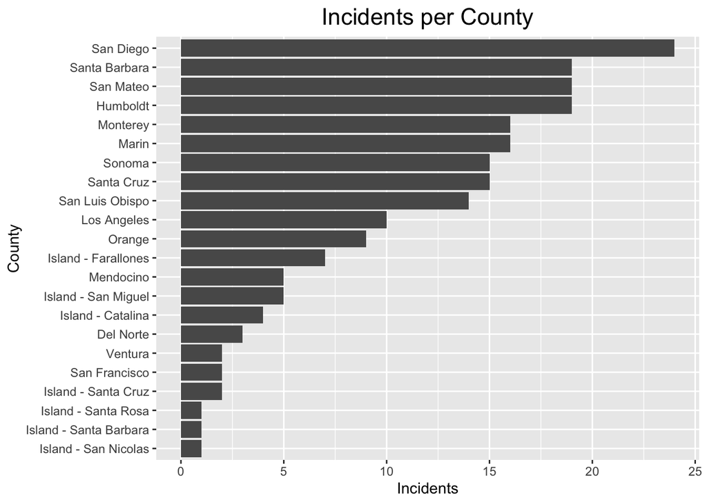

```r
sharks %>%
 group_by(county) %>%
  summarize(total_incidents = n_distinct(incident_num)) %>%
  arrange(desc(total_incidents)) %>%
  ggplot(aes(x=reorder(county, total_incidents), y=total_incidents))+
  geom_col()+
  coord_flip()+
  labs(title = "Incidents per County",
       x="County",
       y="Incidents")+
  theme(plot.title = element_text(size=rel(1.5), hjust=.5))
```

4. Are there months of the year when incidents are more likely to occur? Make a table and a plot that shows the total number of incidents by month. Which month has the highest number of incidents?

```r
sharks %>%
  group_by(month) %>%
  summarize(total_incident_month = n_distinct(incident_num)) %>%
  arrange(-total_incident_month)
```

```
## # A tibble: 12 × 2
##    month total_incident_month
##    <dbl>                <int>
##  1    10                   36
##  2     9                   32
##  3     8                   31
##  4     7                   24
##  5     5                   16
##  6    11                   16
##  7     6                   14
##  8    12                   13
##  9     1                    8
## 10     4                    7
## 11     3                    5
## 12     2                    4
```

October has the highest number of incidents

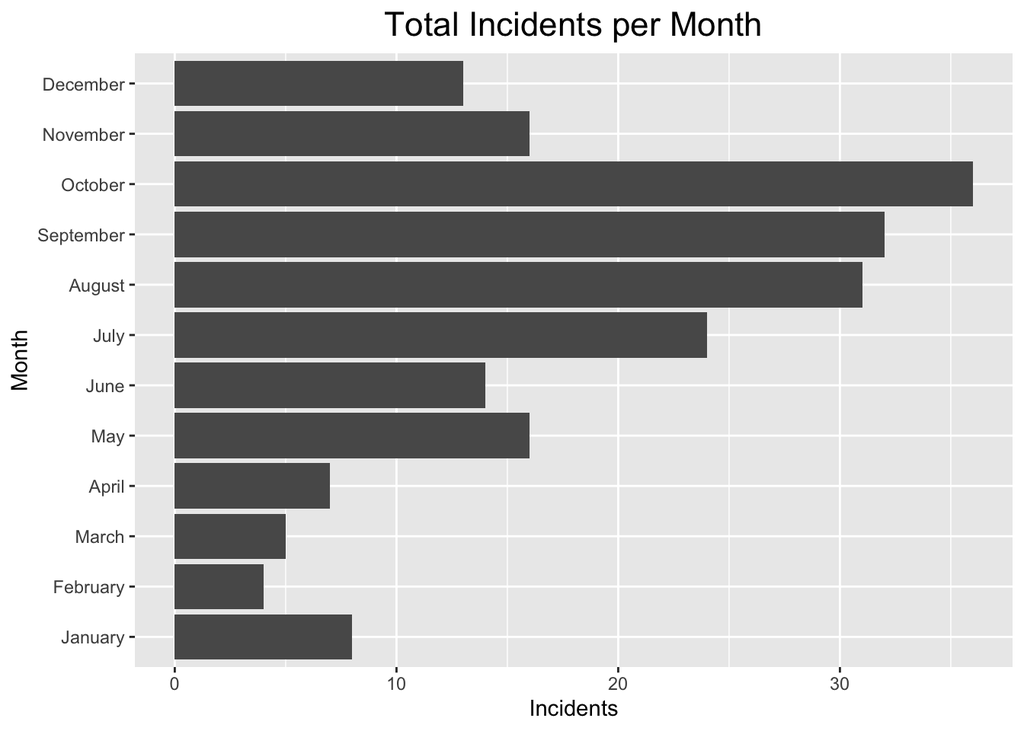

```r
sharks %>%
  mutate(month = factor(month, levels = 1:12, labels = month.name)) %>%
  group_by(month) %>%
  summarize(total_incident_month = n_distinct(incident_num)) %>%
  ggplot(aes(x=month, y=total_incident_month))+ #x = as_factor(month)
  geom_col()+
  coord_flip()+
  labs(title = "Total Incidents per Month",
       x="Month",
       y="Incidents")+
  theme(plot.title = element_text(size=rel(1.5), hjust=.5))
```

5. How do the number and types of injuries compare by county? Make a table that shows the number of injury types by county. Which county has the highest number incidents?

```r
sharks %>%
  select(county, injury) %>%
  group_by(county, injury) %>%
  summarize(total=n(), .groups = 'keep') %>%
  pivot_wider(names_from = injury, values_from = total) %>%
  mutate(total_incidents = sum(minor, major, fatal, none, na.rm=T)) %>%
  arrange(-total_incidents)
```

```
## # A tibble: 22 × 7
## # Groups:   county [22]
##    county          minor  none major  `NA` fatal total_incidents
##    <chr>           <int> <int> <int> <int> <int>           <int>
##  1 San Diego           8     9     4     2     2              23
##  2 Santa Barbara       6     9     2    NA     2              19
##  3 Humboldt            2     9     7     2    NA              18
##  4 San Mateo           4    12     1     1     1              18
##  5 Marin               4     3     9    NA    NA              16
##  6 Monterey            2     3     8     1     2              15
##  7 Santa Cruz          3     8     3    NA     1              15
##  8 Sonoma              1     6     8    NA    NA              15
##  9 San Luis Obispo     1     7     3    NA     3              14
## 10 Los Angeles         6     2    NA     1     1               9
## # ℹ 12 more rows
```

San Diego

6. Use the table from #5 to make a plot that shows the total number of incidents by county.

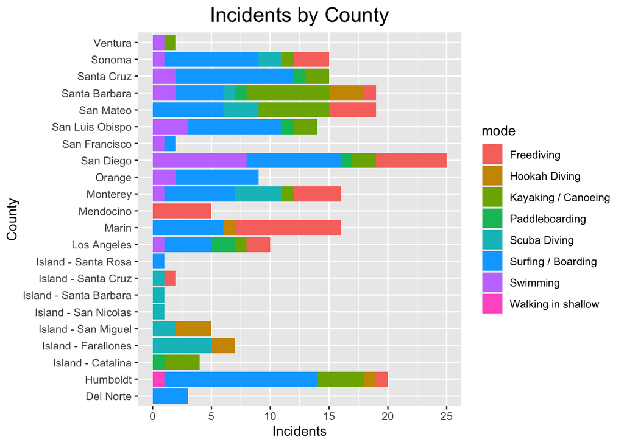

```r
sharks %>%
  ggplot(aes(x=county, fill = mode))+
  geom_bar()+
  coord_flip()+
  labs(title = "Incidents by County",
       x="County",
       y="Incidents")+
  theme(plot.title = element_text(size=rel(1.5), hjust=.5))
```

7. In the data, `mode` refers to a type of activity. Which activity is associated with the highest number of incidents?

```r
sharks %>%
  group_by(mode) %>%
  summarize(total_incident = n_distinct(incident_num)) %>%
  arrange(-total_incident)
```

```
## # A tibble: 8 × 2
##   mode                total_incident
##   <chr>                        <int>
## 1 Surfing / Boarding              81
## 2 Freediving                      36
## 3 Kayaking / Canoeing             30
## 4 Swimming                        22
## 5 Scuba Diving                    20
## 6 Hookah Diving                   10
## 7 Paddleboarding                   7
## 8 Walking in shallow               1
```

Surfing / Boarding is associated with the highest number of incidents

8. Make a plot that compares the number of incidents by activity.

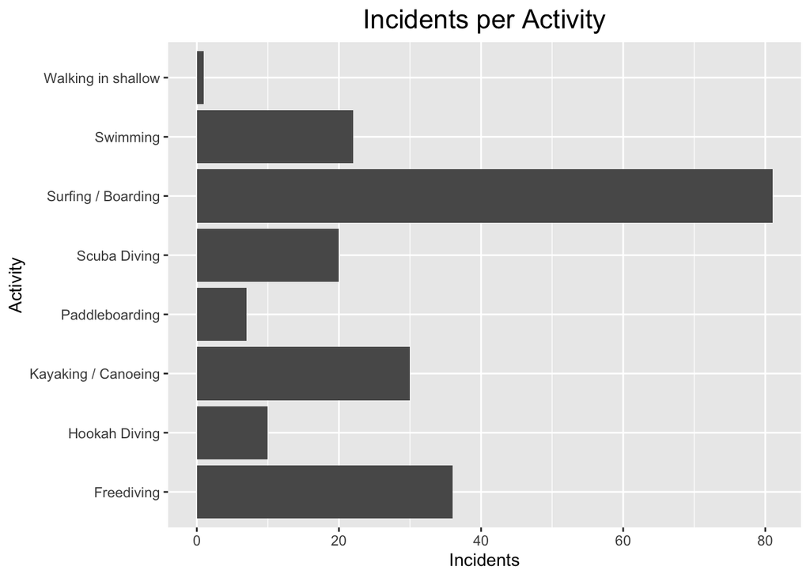

```r
sharks %>%
  group_by(mode) %>%
  summarize(total_incident = n_distinct(incident_num)) %>%
  ggplot(aes(x=mode, y=total_incident))+
  geom_col()+
  coord_flip()+
  labs(title = "Incidents per Activity",
       x="Activity",
       y="Incidents")+
  theme(plot.title = element_text(size=rel(1.5), hjust=.5))
```

9. Which shark species is involved in the highest number of incidents?

```r
sharks %>%
  group_by(species) %>%
  summarize(total_incident = n_distinct(incident_num)) %>%
  arrange(-total_incident)
```

```
## # A tibble: 12 × 2
##    species      total_incident
##    <chr>                 <int>
##  1 White                   180
##  2 Unknown                  14
##  3 Hammerhead                3
##  4 Blue                      2
##  5 Leopard                   2
##  6 Salmon                    2
##  7 Blue*                     1
##  8 Killer Whale              1
##  9 Mako                      1
## 10 Sevengill                 1
## 11 Thresher                  1
## 12 blue                      1
```

Great Whites are involved in the highest number of incidents.

10. Are all incidents involving Great White’s fatal? Make a plot that shows the number and types of incidents for Great White’s only.

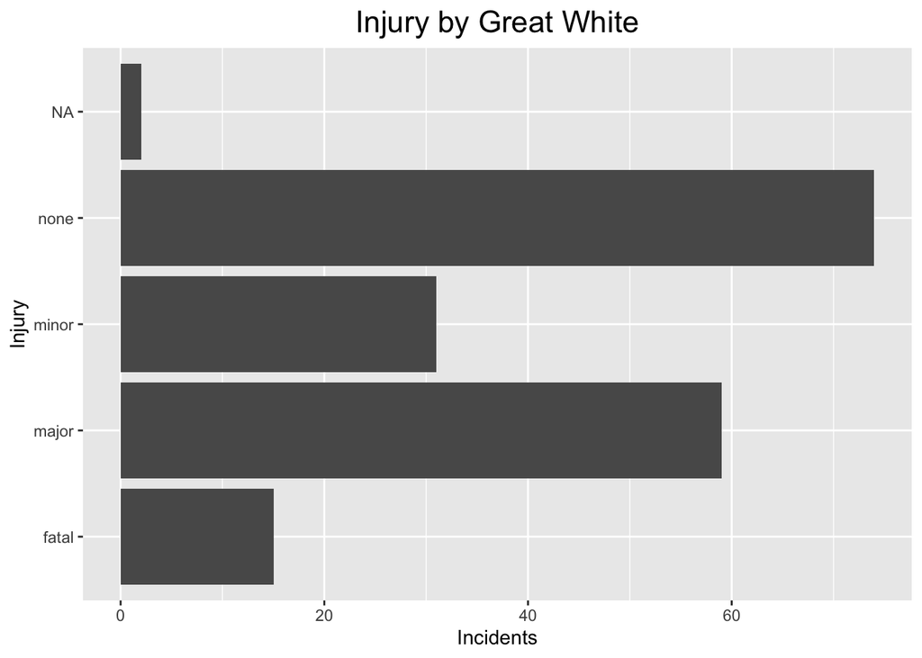

```r
sharks %>%
  filter(species=="White") %>%
  ggplot(aes(x=injury))+
  geom_bar()+
  coord_flip()+
  labs(title = "Injury by Great White",
       x="Injury",
       y="Incidents")+
  theme(plot.title = element_text(size=rel(1.5), hjust=.5))
```

[output not shown]